# In_class_activity_Week9

2026-03-25

```r
rm(list=ls())
```

## Activity 2

- First we need to calculate the analytical form of the inverse CDF of the weibull distribution with parameters $k$ and $\lambda$

To do this we use a simple method:

Suppose

$$y = 1-e^{-(x/\lambda)^k}$$
Then,

$$\begin{align}
e^{-(x/\lambda)^k} &= 1 - y\\
-(x/\lambda)^k &= \log(1 - y)\\
(x/\lambda)^k &= -\log(1 - y)\\
x/\lambda &= (-\log(1 - y))^{\frac{1}{k}}\\
x &= \lambda(-\log(1 - y))^{\frac{1}{k}}\\
\end{align}$$

So now we have:

$$F^{-1}(U) = \lambda(-\log(1 -
U))^{\frac{1}{k}}$$
Where $U \sim \text{Unif}(0,1)$

Thus, we first write a function that computes this inverse CDF

```r
# inverse weibull CDF
inverse_weibull <- function(U, lambda, k) {
  return(lambda * (-log(1 - U))^(1/k))
}
```

Then we wrap it in a generator function

```r
# generator n samples using inverse CDF
generate_weibull <- function(n, lambda, k) {
  U <- runif(n)                        # sample n draws from U(0,1)
  return(inverse_weibull(U, lambda, k)) # apply inverse CDF
}
```

Now we generate 10000 samples from this weibull distribution using the inverse CDF method

```r
set.seed(123)
k      <- 2
lambda <- 3
n      <- 10000

weibull_samples <- generate_weibull(n, lambda, k)
```

To verify, we plot the theoretical distribution versus the simulated distribution

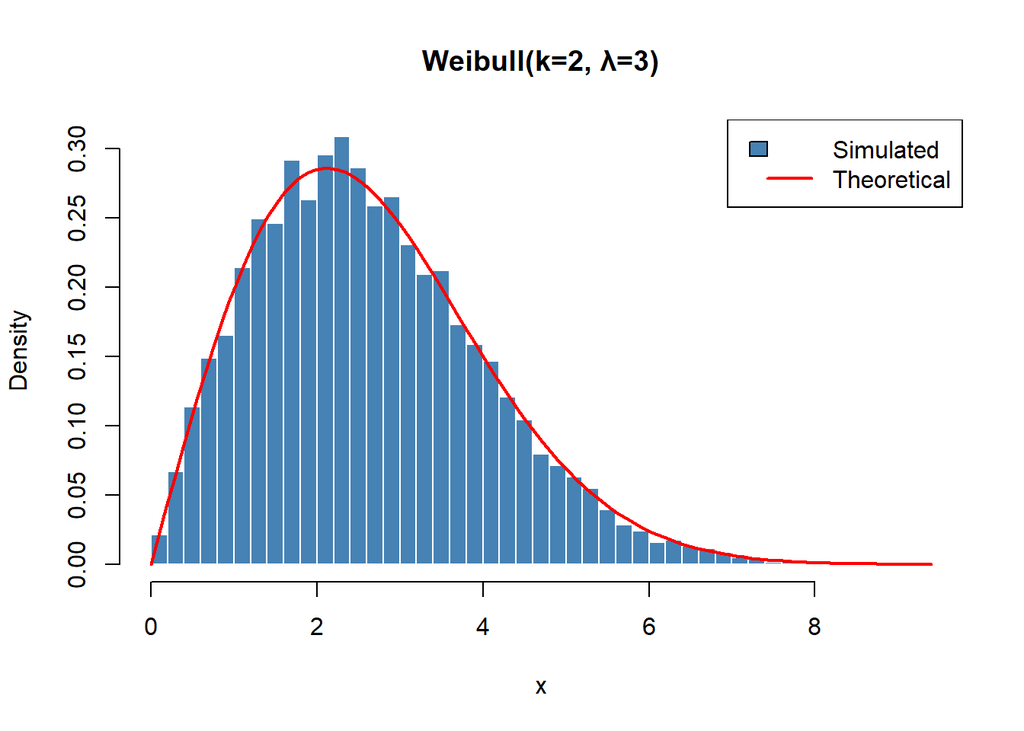

```r
# plot historgram for weibull samples
hist(weibull_samples, breaks = 60, freq = FALSE,
     main = paste0("Weibull(k=", k, ", λ=", lambda, ")"),
     xlab = "x", col = "steelblue", border = "white")
# plot a line for true weibull distribution
curve(dweibull(x, shape = k, scale = lambda),
      add = TRUE, col = "red", lwd = 2)

legend("topright", legend = c("Simulated", "Theoretical"),
       fill = c("steelblue", NA), border = c("black", NA),
       lty = c(NA, 1), col = c(NA, "red"), lwd = c(NA, 2))
```

And we can see that the distribution of the simulated samples follow an empirical distribution very well aligned to the actual distribution.

## Activity 3

### I. Density function

Recall: the target density is

$$f(x;\eta,\sigma)=\eta\sigma \exp\{\eta+\sigma x-\eta e^{\sigma x}\},
\qquad x\ge 0,$$

We first implement the density function and the first derivative

```r
# --- Gompertz PDF ---
dgompertz <- function(x, eta, sigma) {
  if (eta <= 0 || sigma <= 0) {
    stop("eta and sigma must be positive.")
  }

  log_pdf <- log(eta) + log(sigma) + eta + sigma * x - eta * exp(sigma * x)
  ifelse(x >= 0, exp(log_pdf), 0)
}

# --- Log Gompertz PDF ---
log_dgompertz <- function(x, eta, sigma) {
  ifelse(x >= 0,
         log(eta) + log(sigma) + eta + sigma * x - eta * exp(sigma * x),
         -Inf)
}

# --- d/dx log f(x) ---
dlog_gompertz <- function(x, eta, sigma) {
  sigma - eta * sigma * exp(sigma * x)
}
```

Side Note: I want to verify the density function is correct by plotting some common parameters

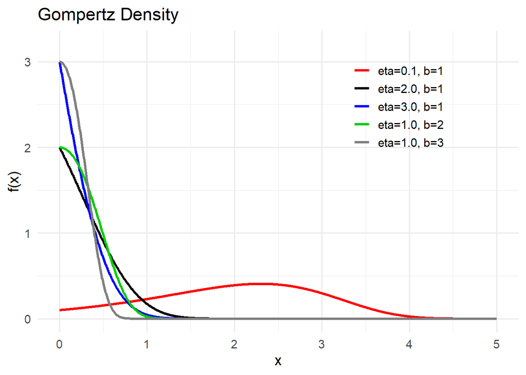

```r
library(ggplot2)
library(tibble)
library(dplyr)
params <- tibble(eta = c(0.1, 2.0, 3.0, 1.0, 1.0),
  sigma = c(1, 1, 1, 2, 3),
  label = c("eta=0.1, b=1", "eta=2.0, b=1", "eta=3.0, b=1", "eta=1.0, b=2", "eta=1.0, b=3"))

x_grid <- seq(0, 5, length.out = 1000)

plot_data <- params %>%
  rowwise() %>%
  reframe(x = x_grid, fx = dgompertz(x_grid, eta, sigma), label = label)

plot_data$label <- factor(plot_data$label, levels = params$label)

ggplot(plot_data, aes(x = x, y = fx, color = label)) +
  geom_line(linewidth = 1.2) +
  scale_color_manual(
    values = c("eta=0.1, b=1" = "red", "eta=2.0, b=1" = "black", "eta=3.0, b=1" = "blue", "eta=1.0, b=2" = "green3", "eta=1.0, b=3" = "gray50")) +
  coord_cartesian(xlim = c(0, 5), ylim = c(0, 3.2)) +
  labs(x = "x", y = "f(x)", color = NULL,
       title = "Gompertz Density") +
  theme_minimal(base_size = 14) +
  theme(legend.position = c(0.75, 0.75))
```

The plot is a bit different from Wikipedia. Might be the scale of y-axis.

where $\eta>0$ and $\sigma>0$.

Generalized rejection sampling states one should pick a proposal density $g(x)$ and a constant $c>0$ s.t.

$$f(x)\le c g(x) \qquad \text{for all } x\ge 0.$$

Then, generate $Y \sim g$, $U \sim \mathrm{Unif}(0,1)$. Accept $Y$ if $U \le \frac{f(Y)}{c g(Y)}.$

From Lange, we observe that we can use piecewise exponential envelopes for log-concave densities.

Now we check that this is applicable for the Gompertz density, taking the log of the density gives:

$$\log f(x)=\log(\eta\sigma)+\eta+\sigma x-\eta e^{\sigma x}.$$

Taking the first derivative and get:

$$\frac{d}{dx}\log f(x)=\sigma-\eta\sigma e^{\sigma x}
=\sigma(1-\eta e^{\sigma x}),$$

and taking second derivative gets:

$$\frac{d^2}{dx^2}\log f(x)
=-\eta\sigma^2 e^{\sigma x}<0 \qquad \text{for all } x\ge 0.$$

Therefore, the Gompertz density is log-concave on $[0,\infty)$.

Now from Lange, it is suggested that the exponential envelope be chosen based on the mode, so let’s calculate the mode first:

Set the first derivative equal to zero:

$$\sigma(1-\eta e^{\sigma x})=0
\quad \Longleftrightarrow \quad
\eta e^{\sigma x}=1
\quad \Longleftrightarrow \quad
x=\frac{1}{\sigma}\log\!\left(\frac{1}{\eta}\right).$$

This gives two cases:

- $\eta \ge 1$, then $\log(1/\eta)\le 0$, since the support is non-negative, mode is at the boundary $x=0$;
- $0<\eta<1$, then $\log(1/\eta)>0$, mode lies in the interior of the support.

This means we need to use both the single exponential envelope and the two-piece exponential envelope depending on value of $\eta$

### II. Define exponential envelope

Based on the derivation above, the generalized rejection sampler is implemented differently depending on whether the mode is at the boundary or in the interior. Observe that for both cases, there are two pieces of exponential envelopes, just the left piece is 0 for the first case, hence a single envelope.

We want to use the tangency condition in Lange to solve for the constants $c_r, c_l, \lambda_r, \lambda_l$

For the first piece, i.e. the piece on the right, the envelope is:

$$h_r(x) = c_r \lambda_r e^{-\lambda_r(x - m)}, \quad x \geq m$$

From Lange, the tangency condition states that the envelope touches $f$ and have the same slope at the tangent point $x_r > m$:

$$f(x_r) = c_r\lambda_r e^{-\lambda_r(x_r - m)} \quad \text{(i)}$$
$$f'(x_r) = -c_r\lambda_r^2 e^{-\lambda_r(x_r - m)} \quad \text{(ii)}$$

We now have 2 equations for 2 unknowns and we can solve for both $lambda_r$ and $c_r$

Dividing (ii) by (i):

$$\frac{f'(x_r)}{f(x_r)} = -\lambda_r \implies \lambda_r =
-\frac{d}{dx}\ln f(x_r)
= \eta\sigma e^{\sigma x_r} - \sigma$$

Now we can substitute $\lambda_r$ back into (i) and solving for $c_r$:

$$c_r(x_r) = -\frac{f(x_r)^2}{f'(x_r)}
e^{-\frac{f'(x_r)}{f(x_r)}(x_r - m)}$$

For the left envelope,

the piece is oriented in the opposite direction — it decreases away from $m$ to the left:

$$h_l(x) = c_l\lambda_l e^{-\lambda_l(m-x)}, \quad x < m$$

We now apply the same tangency logic.

$$\begin{align}
f(x_l) = c_l\lambda_l e^{-\lambda_l(m-x_l)} \quad \text{...(iii)}\\
f'(x_l) = c_l\lambda_l^2 e^{-\lambda_l(m-x_l)} \quad \text{...(iv)}
\end{align}$$
Dividing (iv) by (iii):

$$\frac{f'(x_l)}{f(x_l)} = \lambda_l \implies \lambda_l =
\frac{d}{dx}\ln f(x_l)
= \sigma - \eta\sigma e^{\sigma x_l}$$

Substituting $\lambda_l$ back into (iii) and solving for $c_l$:

$$c_l(x_l) = \frac{f(x_l)^2}{f'(x_l)}
e^{-\frac{f'(x_l)}{f(x_l)}(x_l - m)}$$

### III. Choosing the optimal Tangent points

Now we have $\lambda_r, c_r, \lambda_l, c_l$ as functions of $x_r$ and $x_l$. In principle, any $x_r > m$ and $0 < x_l < m$ gives a valid envelope that majorizes $f$ — the sampler would produce correct Gompertz samples regardless of the choice.

We obversve that the total mass for the two-piece envelope is $c_l + c_r$, and for the one-piece it’s just $c_r$. Then we can infer that the acceptance rate is

$$\frac{1}{c_\text{total}} = \begin{cases}
1/c_r & \eta \geq 1 \\
1/(c_l + c_r) & \eta < 1
\end{cases}$$

So we want to maximize this acceptance rate, by minimizing the denominator:

$$x_r^* = \arg\min_{x_r > m}\ c_r(x_r), \qquad
x_l^* = \arg\min_{0 < x_l < m}\ c_l(x_l)$$

We can do this using the `optimize()` function.

We first write some helper functions that help with this optimization.

```r
# --- c_r(x_r): computed on log scale to avoid underflow ---
mass_cr <- function(xr, m, eta, sigma) {
  log_f <- log_dgompertz(xr, eta, sigma)
  dl    <- dlog_gompertz(xr, eta, sigma)
  if (!is.finite(log_f)) {
    return(Inf)}   # underflow guard
  if (dl >= 0) {
    return(Inf)}
  log_cr <- log_f - log(-dl) - dl * (xr - m)
  exp(log_cr)
}

# --- c_l(x_l): computed on log scale to avoid underflow ---
mass_cl <- function(xl, m, eta, sigma) {
  log_f <- log_dgompertz(xl, eta, sigma)
  dl    <- dlog_gompertz(xl, eta, sigma)
  if (!is.finite(log_f)) {
    return(Inf)}   # underflow guard
  if (dl <= 0) {
    return(Inf)}
  log_cl <- log_f - log(dl) - dl * (xl - m)
  exp(log_cl)
}
```

### IV. construct the envelope

With the above functions of x, mode and parameters, we can finally use optimization to find the boundary $x^{*}_l$ and $x^{*}_r$

```r
# --- get boundaries and get envelope ---
get_envelope <- function(eta, sigma) {
  m <- log(1 / eta) / sigma

  if (eta >= 1) {
    # endpoint case: mode at 0
    opt_r    <- optimize(mass_cr,
                         interval = c(1e-6, 6 / sigma),
                         m = 0, eta = eta, sigma = sigma)
    xr       <- opt_r$minimum
    cr       <- opt_r$objective
    lambda_r <- -dlog_gompertz(xr, eta, sigma)

    list(case = "endpoint", m = 0, xr = xr, lambda_r = lambda_r, cr = cr, cl = 0, c_total  = cr)

  } else {
    # interior case: two-piece envelope
    opt_r    <- optimize(mass_cr,
                         interval = c(m + 1e-6, m + 5 / sigma),
                         m = m, eta = eta, sigma = sigma)
    xr       <- opt_r$minimum
    cr       <- opt_r$objective
    lambda_r <- -dlog_gompertz(xr, eta, sigma)

    opt_l    <- optimize(mass_cl,
                         interval = c(1e-6, m - 1e-6),
                         m = m, eta = eta, sigma = sigma)
    xl       <- opt_l$minimum
    cl       <- opt_l$objective
    lambda_l <- dlog_gompertz(xl, eta, sigma)

    list(case = "interior", m = m, xr = xr, lambda_r = lambda_r, cr = cr, xl = xl, lambda_l = lambda_l, cl = cl, c_total = cl + cr)
  }
}
```

### V. Sample from the Proposal $g(x)$

Now that we are able to use optimization to find the envelope constants, we need to draw samples from the proposal density $g(x)$. The form differs between the two cases.

#### Case 1: Endpoint

The proposal for this case is just the right piece: $g(x) = \lambda_r e^{-\lambda_r x}$, i.e. $Y \sim \text{Exp}(\lambda_r)$. This is simple and we can sample using the inverse CDF:

$$Y = -\frac{1}{\lambda_r}\log(1 - U), \quad U \sim \text{Uniform}(0,1)$$

#### Case 2: Interior

The proposal for this case now is two pieces, we need to write the envelope as a true density, weighing the components:

$$g(x) = \frac{c_l}{c_l+c_r}\lambda_l e^{-\lambda_l(m-x)}\mathbf{1}[x <
m] +
\frac{c_r}{c_l+c_r}\lambda_r e^{-\lambda_r(x-m)}\mathbf{1}[x \geq m]$$

Based on the knowledge of mixture models, we observe this is a weighted two-piece distribution, so we can do these steps to sample from it:

— First, we observe the left piece has probability $p_l = c_l/(c_l + c_r)$, so:

$$n_l \sim \text{Binomial}(n,\ p_l), \quad n_r = n - n_l$$

— Then we just sample from each piece alone by inversion: - Left piece: $Y_l = m - \text{Exp}(\lambda_l)$ - Right piece: $Y_r = m + \text{Exp}(\lambda_r)$

The implementation is as follows, for both situations

```r
# --- Sample from proposal g ---
sample_proposal <- function(n, env) {
  if (env$case == "endpoint") {
    rexp(n, rate = env$lambda_r) # this is the inverse CDF method, I just used the built-in r function to sample from exp(\lamnda_r)

  } else {
    p_left  <- env$cl / env$c_total
    n_left  <- rbinom(1, n, p_left)
    n_right <- n - n_left

    y_left  <- env$m - rexp(n_left,  rate = env$lambda_l)
    y_right <- env$m + rexp(n_right, rate = env$lambda_r)
    y_left  <- pmax(y_left, 0)

    c(y_left, y_right)
  }
}
```

### VI. Build the Rejection Sampler

Now we have every component, we can build the sampler from here.

In rejection sampling, for each proposal $y \sim g$, we accept it with probability $f(y)/h(y)$, i.e. we accept if:

$$U \leq \frac{f(y)}{h(y)}, \quad U \sim \text{Uniform}(0,1)$$

where $h(y)$ is the majorizing function evaluated at $y$:

$$h(y) = \begin{cases}
c_r\lambda_r e^{-\lambda_r y} & \eta \geq 1 \\[6pt]
c_l\lambda_l e^{-\lambda_l(m-y)} & \eta < 1,\ y < m \\[6pt]
c_r\lambda_r e^{-\lambda_r(y-m)} & \eta < 1,\ y \geq m
\end{cases}$$

Now we implement it:

```r
rgompertz <- function(n, eta, sigma) {
  env      <- get_envelope(eta, sigma)
  samples  <- numeric(n)
  accepted <- 0L
  total    <- 0L

  while (accepted < n) {
    y     <- sample_proposal(1, env)
    total <- total + 1L

    # Evaluate envelope h(y)
    if (env$case == "endpoint") {
      hy <- env$cr * env$lambda_r * exp(-env$lambda_r * y)
    } else {
      if (y < env$m) {
        hy <- env$cl * env$lambda_l * exp(-env$lambda_l * (env$m - y))
      } else {
        hy <- env$cr * env$lambda_r * exp(-env$lambda_r * (y - env$m))
      }
    }

    u <- runif(1)
    if (u <= dgompertz(y, eta, sigma) / hy) {
      accepted <- accepted + 1L
      samples[accepted] <- y
    }
  }

  attr(samples, "efficiency") <- accepted / total
  attr(samples, "envelope")   <- env
  return(samples)
}
```

### VII. Do a simulation of 4 combinations of parameters

Given the acceptance rate is $1/c_\text{total}$ varies across parameter combinations because different $(\eta, \sigma)$ values give $f$ a different shape, leading to different optimal tangent points and therefore different $c_\text{total}^*$. So supposedly the efficiency should vary by parameters.

```r
library(tidyverse)
```

```r
library(patchwork)

# --- Define parameter combinations ---
params <- tibble(
  eta   = c(0.1, 0.6, 1.0, 2.0),
  sigma = c(1.0, 0.5, 2.0, 1.0)
)

# --- Run sampler for all combinations ---
set.seed(123)
N <- 10000

samples_list <- map2(params$eta, params$sigma, ~ rgompertz(N, eta = .x, sigma = .y))

# --- Collect results into a table ---
results3 <- params %>%
  mutate(
    case       = map_chr(samples_list, ~ attr(.x, "envelope")$case),
    est_var    = map_dbl(samples_list, var) %>% round(4),
    efficiency_empirical = map_dbl(samples_list, ~ attr(.x, "efficiency")) %>% round(4),
    efficiency_theoretical = map_dbl(samples_list, ~ 1 / attr(.x, "envelope")$c_total) %>% round(4)
  )
print(results3)
```

```
## # A tibble: 4 × 6
##     eta sigma case     est_var efficiency_empirical efficiency_theoretical
##   <dbl> <dbl> <chr>      <dbl>                <dbl>                  <dbl>
## 1   0.1   1   interior  1.16                  0.816                  0.720
## 2   0.6   0.5 interior  1.11                  0.895                  0.358
## 3   1     2   endpoint  0.0441                0.701                  0.704
## 4   2     1   endpoint  0.0791                0.807                  0.812
```

### VIII. Now we plot the simulations

We verify correctness by overlaying the empirical histogram against the true Gompertz density.

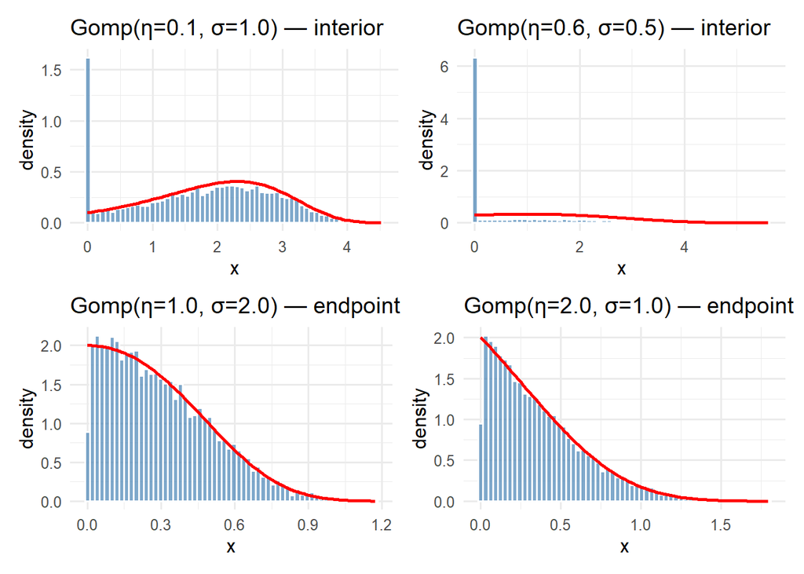

```r
# --- Build histogram + density overlay for each combination ---
plots <- pmap(list(samples_list, params$eta, params$sigma, results3$case),
  function(samps, eta, sigma, case_type) {
    tibble(x = samps) %>%
      ggplot(aes(x = x)) +
      geom_histogram(aes(y = after_stat(density)),
                     bins = 60, fill = "steelblue",
                     color = "white", alpha = 0.7) +
      stat_function(fun  = dgompertz,
                    args = list(eta = eta, sigma = sigma),
                    color = "red", linewidth = 1) +
      labs(title = sprintf("Gomp(η=%.1f, σ=%.1f) — %s", eta, sigma, case_type),
           x = "x", y = "density") +
      theme_minimal(base_size = 12)
  }
)

# --- Combine into 2x2 grid ---
(plots[[1]] + plots[[2]]) / (plots[[3]] + plots[[4]])
```

## Activity 4

The von Mises distribution has density and we can single out the nominator:

$$f(x; \mu, \kappa) = \frac{e^{\kappa \cos(x - \mu)}}{2\pi I_0(\kappa)}
\propto e^{\kappa \cos(x - \mu)} =: h(x; \mu, \kappa)$$

for $x \in (\mu - \pi, \mu + \pi]$, with $\mu \in [\pi, 2\pi]$ and $\kappa > 0$.

According to the ratio-of-uniforms method, the set $C_h$ is a desired set in the form:

$$C_h = \{(u, v) : 0 < u \leq \sqrt{h(v/u; \mu, \kappa)}\}$$

This set will give us the target distribution from the ratio of uniform variables. We need to find two bounding polygons $C_1$ and $C_2$ such that $C_h \subset C_1$ and $C_h \subset C_2$.

### Deriving Parameters for C_1:

$C_1$ is a rectangle $[0, x_u] \times [y_l, y_u]$

- Finding $x_u$

We can see that the right bound of the rectangle is $x_u$, so finding $x_u$ is equivalent to finding the maximum value of $u$ over all $(u,v) \in C_h$. Since $u \leq \sqrt{h(v/u)}$, letting $x = v/u$ we get the supreme $\sup u = \sqrt{h(x)}$, then we need to maximize $\sqrt{h(x)$

$$x_u = \sup_{x \in (\mu - \pi, \mu + \pi]} \sqrt{h(x)} = \sup_x e^{\kappa
\cos(x - \mu)/2}$$

The exponential term is maximized when $\cos(x - \mu)$ is maximized, which occurs at $x = \mu$ where $\cos(x - \mu) = 1$. Therefore:

$$x_u = e^{\kappa / 2}$$

- Finding $y_u$ and $y_l$

For any point $(u, v) \in C_h$, we have $v = xu$ where $x = v/u$ and $u \leq \sqrt{h(x)}$. So:

$$v = x \cdot u \leq x \cdot \sqrt{h(x)} = x \cdot e^{\kappa \cos(x -
\mu)/2} =: g(x)$$

Similarly, $v = x \cdot u \geq x \cdot 0^+$, but since $v$ can take both signs when $x$ ranges over $(\mu - \pi, \mu + \pi]$, so finding $y_u$ and $y_l$ is euivalent to fining both the sup and inf of $g(x)$.

Therefore:

$$y_u = \sup_{x \in (\mu - \pi, \mu + \pi]} g(x), \qquad y_l = \inf_{x \in
(\mu - \pi, \mu + \pi]} g(x)$$

Now we cannot see the extremes directly, we take the derivative of $g$:

$$g'(x) = \frac{d}{dx} \left[ x \cdot e^{\kappa \cos(x - \mu)/2}
\right] = e^{\kappa \cos(x - \mu)/2} \left[ 1 - \frac{\kappa}{2} x
\sin(x - \mu) \right]$$

Since the exponential factor is always positive, the critical points are where the other term is 0:

$$1 - \frac{\kappa}{2} x \sin(x - \mu) = 0 \quad \Longleftrightarrow \quad
\frac{\kappa}{2} x \sin(x - \mu) = 1$$

We still cannot solve this analytically, so we solve it numerically using `optimize()`. Let $x_{\max}^*$ and $x_{\min}^*$ denote the maximizer and minimizer of $g$. Then:

$$y_u = g(x_{\max}^*) = x_{\max}^* \cdot e^{\kappa \cos(x_{\max}^* -
\mu)/2}$$

$$y_l = g(x_{\min}^*) = x_{\min}^* \cdot e^{\kappa \cos(x_{\min}^* -
\mu)/2}$$

### Deriving Parameters for C_2:

Now, we can see that for $C_2$, the banded region is defined as $\{(u, \beta_1 u \pm \beta_0) : 0 < u \leq x_u\}$:

$$C_2 = \{(u, v) : 0 < u \leq x_u, \; |v - \beta_1 u| \leq \beta_0 \}$$

For $x_u$, we can see that it is the same $x_u = e^{\kappa/2}$ as $C-1$.

Now we need to find the other two parameters.

- Finding $\beta_1$

Here we can see $v = \beta_1 u$ is like the center line of the shape. Thus, we want it to be at the most concentrated part part of $C_h$. Since $v = xu$ and the mode of $h(x)$ is at $x = \mu$ where $\cos(x - \mu)$ is maximized, the line $v = \mu u$ is where we should put our optimum:

$$\beta_1 = \mu$$

- Finding $\beta_0$

We need the minimum $\beta_0$ such that the band contains all of $C_h$. For any $(u, v) \in C_h$, the distance from the center line is:

$$|v - \beta_1 u| = |v - \mu u| = |x - \mu| \cdot u$$

where $x = v/u$. Since $u \leq \sqrt{h(x)} = e^{\kappa \cos(x - \mu)/2}$, this distance is bounded by:

$$|x - \mu| \cdot u \leq |x - \mu| \cdot e^{\kappa \cos(x - \mu)/2}$$

So we need $\beta_0$ to be at least as large as the supremum of this term above. Now we substitute $t = x - \mu$ where $t \in (-\pi, \pi]$ and get:

$$\beta_0 = \sup_{t \in (-\pi, \pi]} |t| \cdot e^{\kappa \cos(t)/2}$$

To find the critical points, we need to differentiate the objective function:

$$\frac{d}{dt} \left[ t \cdot e^{\kappa \cos(t)/2} \right] = e^{\kappa
\cos(t)/2} \left[ 1 - \frac{\kappa}{2} t \sin(t) \right]$$

Setting this to zero gives the same equation as in $C_1$:

$$\frac{\kappa}{2} t \sin(t) = 1$$

This means we still ues `optimize()` to solve for it.

We optimize over $t \in (0, \pi]$ and $t \in [-\pi, 0)$ separately and take the larger value. Let $t^*$ be the maximizer. Then:

$$\beta_0 = |t^*| \cdot e^{\kappa \cos(t^*)/2}$$

### Now we start the implementation:

```r
#' Draw Random Samples from a Von Mises Distribution
#'
#' @param n number of random deviates
#' @param mu mean parameter (>= pi)
#' @param kappa concentration parameter (> 0)
#' @param type type of polygon to use (either 1 or 2)
#' @return a vector of length `n`, with an attribute *efficiency* giving
#'     the sampling efficiency for this draw.
rvonmises <- function(n, mu, kappa, type) {

  # --- Define h(x) and support ---
  # h(x) = exp(kappa * cos(x - mu)), Support: (mu - pi, mu + pi]
  lowerb <- mu - pi + 1e-10
  upperb <- mu + pi

  # --- Compute x_u ---
  # x_u is the same for both C_1 and C_2
  # x_u = max sqrt(h(x)) = exp(kappa/2), acquired at x = mu
  x_u <- exp(kappa / 2)

  # --- Compute y_l and y_u ---
  # g(x) = x * sqrt(h(x)) = x * exp(kappa * cos(x - mu) / 2)
  # y_u = max g(x), y_l = min g(x), solved numerically
  g <- function(x) x * exp(kappa * cos(x - mu) / 2)
  y_u <- optimize(g, interval = c(lowerb, upperb), maximum = TRUE)$objective
  y_l <- optimize(g, interval = c(lowerb, upperb), maximum = FALSE)$objective

  # --- For C_2, also compute beta0 and beta1 ---
  if (type == 2) {
    beta1 <- mu
    # beta0 = max |x - mu| * exp(kappa * cos(x - mu) / 2)
    g2 <- function(x) abs(x - mu) * exp(kappa * cos(x - mu) / 2)
    opt_left  <- optimize(g2, interval = c(lowerb, mu), maximum = TRUE)
    opt_right <- optimize(g2, interval = c(mu, upperb), maximum = TRUE)
    beta0 <- max(opt_left$objective, opt_right$objective)
  }

  # --- Accept-reject while loop step up ---
  samples <- numeric(n)
  total_proposals <- 0
  accepted <- 0

  # --- Accept-reject loop beigins ---
  while (accepted < n) {
    # Step 1: Generate U1, U2 ~ U(0,1)
    U1 <- runif(1)
    U2 <- runif(1)

    # Step 2: Map to (u, v) in the bounding polygon
    u <- x_u * U1

    if (type == 1) {
      # C_1 is a rangtangle: v ~ U(y_l, y_u)
      v <- y_l + (y_u - y_l) * U2
    } else {
      # C_2 is a banded shape: v = beta1 * u + U(−beta0, beta0)
      v <- beta1 * u + (2 * U2 - 1) * beta0
    }

    total_proposals <- total_proposals + 1

    # Step 3: Accept if (u, v) in C_h
    # Check u <= sqrt(h(v/u)), this is equivalent to 2*log(u) <= kappa*cos(v/u - mu), hence implemented this way.
    # Also check x = v/u is in the support
    x <- v / u
    if (x > lowerb && x <= upperb && 2 * log(u) <= kappa * cos(x - mu)) {
      accepted <- accepted + 1
      samples[accepted] <- x
    }
  }

  attr(samples, "efficiency") <- n / total_proposals
  return(samples)
}
```

Now we run a test for different combinations of parameters.

```r
# --- Quick test ---
set.seed(123)

cat("=== Test with mu = pi, kappa = 0.5 ===\n")
```

```
## === Test with mu = pi, kappa = 0.5 ===
```

```r
x1 <- rvonmises(10000, mu = pi, kappa = 0.5, type = 1)
cat("C1 (rectangle) efficiency:", attr(x1, "efficiency"), "\n")
```

```
## C1 (rectangle) efficiency: 0.5444844
```

```r
x2 <- rvonmises(10000, mu = pi, kappa = 0.5, type = 2)
cat("C2 (banded)    efficiency:", attr(x2, "efficiency"), "\n")
```

```
## C2 (banded)    efficiency: 0.5307011
```

```r
cat("\n=== Test with mu = 2*pi, kappa = 0.5 ===\n")
```

```
##
## === Test with mu = 2*pi, kappa = 0.5 ===
```

```r
x3 <- rvonmises(10000, mu = 2*pi, kappa = 0.5, type = 1)
cat("C1 (rectangle) efficiency:", attr(x3, "efficiency"), "\n")
```

```
## C1 (rectangle) efficiency: 0.3548364
```

```r
x4 <- rvonmises(10000, mu = 2*pi, kappa = 0.5, type = 2)
cat("C2 (banded)    efficiency:", attr(x4, "efficiency"), "\n")
```

```
## C2 (banded)    efficiency: 0.5332196
```

```r
cat("\n=== Test with mu = pi, kappa = 2 ===\n")
```

```
##
## === Test with mu = pi, kappa = 2 ===
```

```r
x5 <- rvonmises(10000, mu = pi, kappa = 2, type = 1)
cat("C1 (rectangle) efficiency:", attr(x5, "efficiency"), "\n")
```

```
## C1 (rectangle) efficiency: 0.2958055
```

```r
x6 <- rvonmises(10000, mu = pi, kappa = 2, type = 2)
cat("C2 (banded)    efficiency:", attr(x6, "efficiency"), "\n")
```

```
## C2 (banded)    efficiency: 0.7564297
```

```r
# check the mean of the empirical distribution
cat("\nSample mean:", mean(x1), "\n")
```

```
##
## Sample mean: 3.132217
```

```r
cat("Sample mean:", mean(x3), "\n")
```

```
## Sample mean: 6.565791
```